# Chapter 7 - Multivariate Normal Distribution: computer exercises

Author

Prof. Richard Wilkinson

### Task 1

Download the wine dataset from the [UCI Machine Learning Repository](https://archive.ics.uci.edu/ml/datasets/wine)

```r
download.file(url="https://archive.ics.uci.edu/ml/machine-learning-databases/wine/wine.data", destfile="wine.data")
wine <- read.csv("wine.data", header=FALSE)
colnames(wine) <- c("Type", "Alcohol", "Malic",
"Ash",
"Alcalinity",
"Magnesium",
"Phenols",
"Flavanoids",
"Nonflavanoids",
"Proanthocyanins",
"Color",
"Hue",
"Dilution",
"Proline")
```

1. Let’s assume this selection of wines is a random sample from the population of all possible wines. Conduct a multivariate hypothesis test to see whether the average wine has an alcohol content different from 13 and an Malic acid content different from 2?

**Solution**

We will use Hotelling’s $T^2$ one sample test:

```r
library(dplyr)
library(ICSNP) # you'll need to install this package the first time

AlcoMalic <- wine |> dplyr::select(Alcohol, Malic)
colMeans(AlcoMalic)
```

```
  Alcohol     Malic
13.000618  2.336348
```

```r
mu=c(13,2)

HotellingsT2(AlcoMalic,  mu = mu)
```

```
    Hotelling's one sample T2-test

data:  AlcoMalic
T.2 = 8.0904, df1 = 2, df2 = 176, p-value = 0.0004351
alternative hypothesis: true location is not equal to c(13,2)
```

So there is strong evidence to reject the null hypothesis that the alcohol content is 13 **and** the malic acid content is 2.

2. Test whether the alcohol and malic acid content are significantly different between wines of type 1 and wines of type 2.

**Solution**

We’ll now use the Hotelling’s $T^2$ two sample test.

```r
X1 <- wine |> dplyr::filter(Type==1) |> dplyr::select(Alcohol, Malic)
X2 <- wine |> dplyr::filter(Type==2) |> dplyr::select(Alcohol, Malic)

colMeans(X1)
```

```
  Alcohol     Malic
13.744746  2.010678
```

```r
colMeans(X2)
```

```
  Alcohol     Malic
12.278732  1.932676
```

```r
HotellingsT2(X1, X2)
```

```
    Hotelling's two sample T2-test

data:  X1 and X2
T.2 = 135.16, df1 = 2, df2 = 127, p-value < 2.2e-16
alternative hypothesis: true location difference is not equal to c(0,0)
```

So we find overwhelming evidence that wines of type 1 and type 2 have different alcohol and malic acid content.

### Task 2

The command `rWishart` can be used to simulate from a Wishart distribution. Alternatively, to sample from $W_p(\boldsymbol{\Sigma},n)$, you can sample $\mathbf x_1, \ldots, \mathbf x_n \sim N_p(\boldsymbol 0, \boldsymbol{\Sigma})$ and set $\mathbf M= \sum \mathbf x_i \mathbf x_i^\top$.

1. Generate 10,000 samples $M_1, \ldots,$ from a $W_2(\boldsymbol{\Sigma}, 10)$ distribution with $\boldsymbol{\Sigma}= \operatorname{diag}(2,1)$ using these two approaches. Compute the mean and variance of the two samples and check these accord with Proposition 7.6.

**Solution**

```r
Sigma <- diag(c(2,1))
out1 <- rWishart(10^4, 10, Sigma)
out2 <-replicate(10^4, {
  X<- cbind(rnorm(10,0,sd=sqrt(2)), rnorm(10,0,1))
  t(X)%*%X
  })
```

Let’s first compare the means

```r
apply(out1,c(1,2),mean)
```

```
            [,1]        [,2]
[1,] 19.82970534 -0.03174472
[2,] -0.03174472 10.00720567
```

```r
apply(out2,c(1,2),mean)
```

```
            [,1]        [,2]
[1,] 20.05015451 -0.01363671
[2,] -0.01363671  9.97249362
```

According to the proposition in the notes the expected value is
$${\mathbb{E}}W_2(\boldsymbol{\Sigma},n) = n\boldsymbol{\Sigma}$$

```r
10*Sigma
```

```
     [,1] [,2]
[1,]   20    0
[2,]    0   10
```

which appears correct.

Now let’s check variances

```r
apply(out1,c(1,2),var)
```

```
         [,1]     [,2]
[1,] 79.72213 19.91716
[2,] 19.91716 19.75662
```

```r
apply(out2,c(1,2),var)
```

```
         [,1]     [,2]
[1,] 80.37403 19.77536
[2,] 19.77536 19.77715
```

According to the proposition this should be
$${\mathbb{V}\operatorname{ar}}(m_{ij}) = n \left(\sigma_{ij}^2+\sigma_{ii}\sigma_{jj} \right)$$

```r
10*(Sigma^2+matrix(c(4,2,2,1), nr=2))
```

```
     [,1] [,2]
[1,]   80   20
[2,]   20   20
```

which again agrees.

2. Set $\mathbf a= (1\; 1)^\top$. Check empirically that $\mathbf a^\top \mathbf M\mathbf a\sim 3 \chi^2_{10}$. **Hint** plot the theoretical densities on top of a histogram of the sampled quantities.

**Solution**

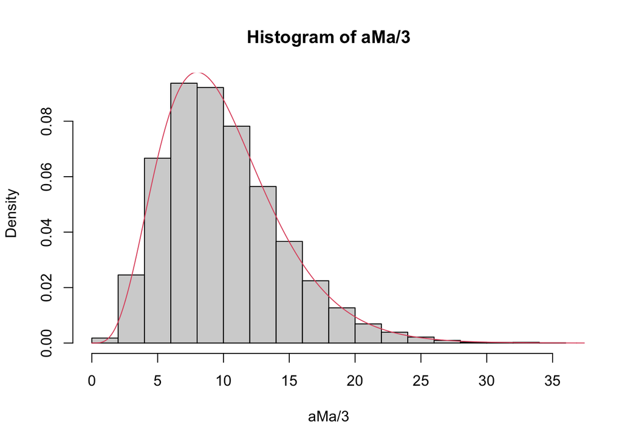

```r
a = matrix(c(1,1), nc=1)
aMa = apply(out2,3, function(x) t(a)%*%x%*%a)
hist(aMa/3, probability = TRUE)
xplt <- seq(0,50,0.01)
lines(xplt, dchisq(xplt, df=10), col=2)
```

3. Suppose $\mathbf x_1, \ldots, \mathbf x_{10} \sim N_2(\boldsymbol 0, \operatorname{diag}(2,1))$. Empirically check that Proposition 7.10 is true by computing the covariance matrix of a large number of such samples, and comparing this to the mean and variance of the Wishart distribution specified in the proposition.

**Solution**

```r
out3 <-replicate(10^4, {
  X<- cbind(rnorm(10,0,sqrt(2)), rnorm(10,0,1))
  t(sweep(X, 2, colMeans(X)))%*%sweep(X, 2, colMeans(X))
  })
apply(out3,c(1,2),mean)
```

```
            [,1]        [,2]
[1,] 18.05218592 -0.01945595
[2,] -0.01945595  8.94744088
```

which agrees with the property that ${\mathbb{E}}W_p(\boldsymbol{\Sigma}, n-1)=(n-1)\boldsymbol{\Sigma}=\begin{pmatrix}18&0\\0&9\end{pmatrix}$. Similarly

```r
apply(out3,c(1,2),var)
```

```
         [,1]     [,2]
[1,] 71.14531 17.67286
[2,] 17.67286 18.27177
```

which agrees with the property ${\mathbb{V}\operatorname{ar}}w_{ij}=(n-1)(\sigma^2_{ij}+\sigma_{ii}\sigma_{jj})= 9\begin{pmatrix}4+4 &0+2\\ 0+2&1+1\end{pmatrix}=\begin{pmatrix}72 &18\\18&18\end{pmatrix}$

4. Similarly, validate Corollary 7.4 by comparing the distribution of $\gamma^2$ with a $F_{p, n-p}$ distribution.

**Solution**

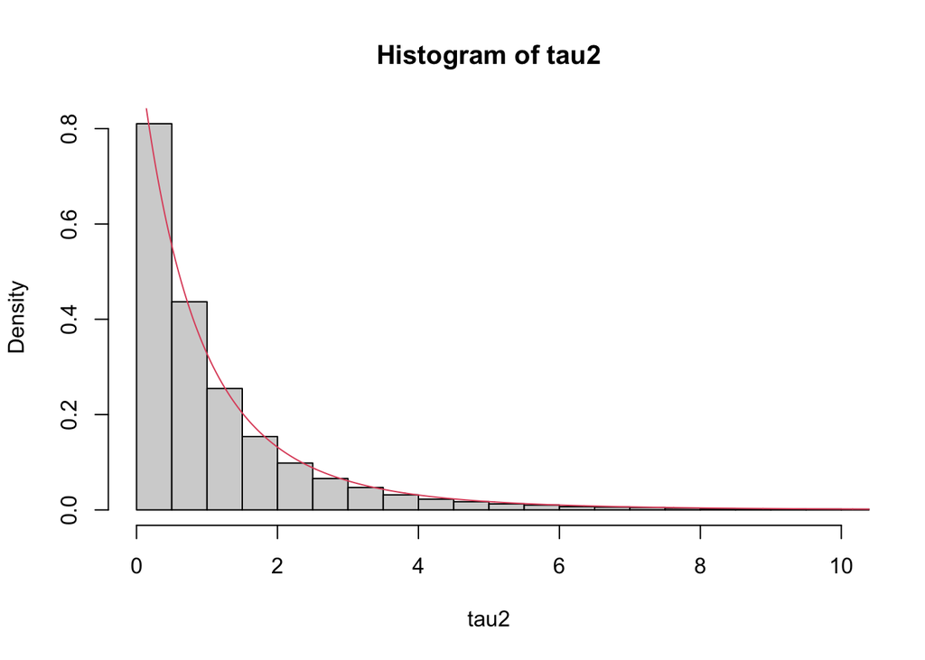

```r
tau2 <- replicate(10^5,{
  X=mvtnorm::rmvnorm(n=10, mean=c(0,0), sigma=diag(c(2,1)))
  #X<- cbind(rnorm(10,0,sqrt(2)), rnorm(10,0,1))
  xbar <- colMeans(X)
  S <- cov(X)
  t(xbar-c(0,0))%*%solve(S)%*%(xbar-c(0,0))*8/2
})
hist(tau2, 100,probability = T, xlim=c(0,10))
lines(xplt, df(xplt, df1=2, df2=8), col=2)
```

### Task 3

Download the exam data from Moodle.

```r
library(dplyr)
load(file='exam.rda')
N<-dim(exam)[1]
```

```r
G100 <- exam |> dplyr::filter(Programme =='G100')
G103 <- exam |> dplyr::filter(Programme =='G103')
n <- dim(G100)[1]
m <- dim(G103)[1]
N <- n+m
```

We will now work through how to plot the confidence regions shown in the notes.

1. Firstly, let’s plot a circle with equation
   $$x^2+y^2=c^2$$
   or in vector form:
   $$\mathbf x^\top\mathbf x=c^2.$$

**Solution**

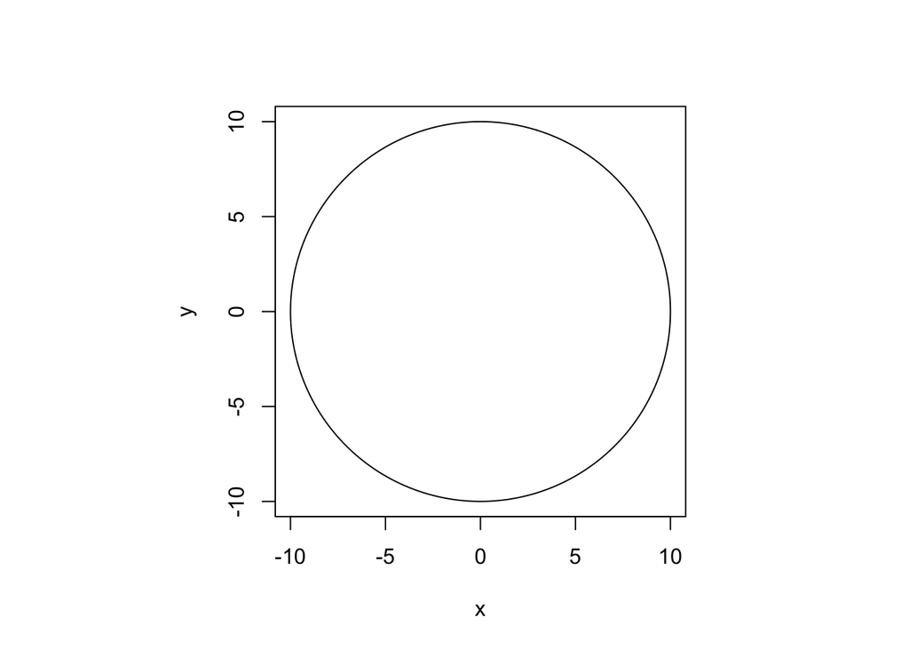

```r
theta <- seq(0, 2*pi, 0.01)
x<- 10*cos(theta)
y <- 10*sin(theta)
par(pty="s")
plot(x,y,type='l')
```

2. Let’s now plot the ellipse
   $$\mathbf x^\top \mathbf S^{-1}\mathbf x=c^2$$
   where $\mathbf S$ is the covariance matrix for the exam data.

   We can do this by noting that $\mathbf u= \mathbf S^{-1/2}\mathbf x$ obeys the equation
   $$\mathbf u^\top\mathbf u=c^2,$$
   i.e., a circle. Thus you can plot an ellipse by using the code above to generate a circle, and then transforming it to be an ellipse. Plot the ellipse for $\mathbf S$ given by the sample covariance matrix of the data.

**Solution**

Let’s start by finding the square root of the covariance matrix. We can do this via an eigendecomposition or using a package:

```r
S <- cov(exam[,1:2])
S.eig <- eigen(S)
(Ssqrt <- S.eig$vectors %*% diag(sqrt(S.eig$values)) %*% t(S.eig$vectors))
```

```
          [,1]      [,2]
[1,] 12.819941  5.252603
[2,]  5.252603 16.955025
```

```r
library(expm)
(S12 <- sqrtm(S))
```

```
          [,1]      [,2]
[1,] 12.819941  5.252603
[2,]  5.252603 16.955025
```

Lets now set $\mathbf x= \mathbf S^{1/2}\mathbf u$ where $\mathbf u$ are points on the circle.

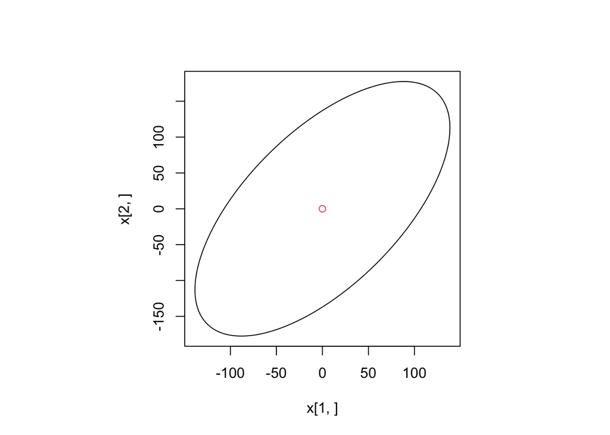

```r
u1<- 10*cos(theta)
u2 <- 10*sin(theta)
u <- rbind(u1,u2)


x <- Ssqrt%*% u
par(pty="s")
plot(x[1,],x[2,],type='l')
points(0,0,col=2)
```

3. What are the major and minor axes of this ellipse?

**Solution**

The major axis is in the direction of the largest eigenvector, and the minor axis in the direction of the other eigenvector.

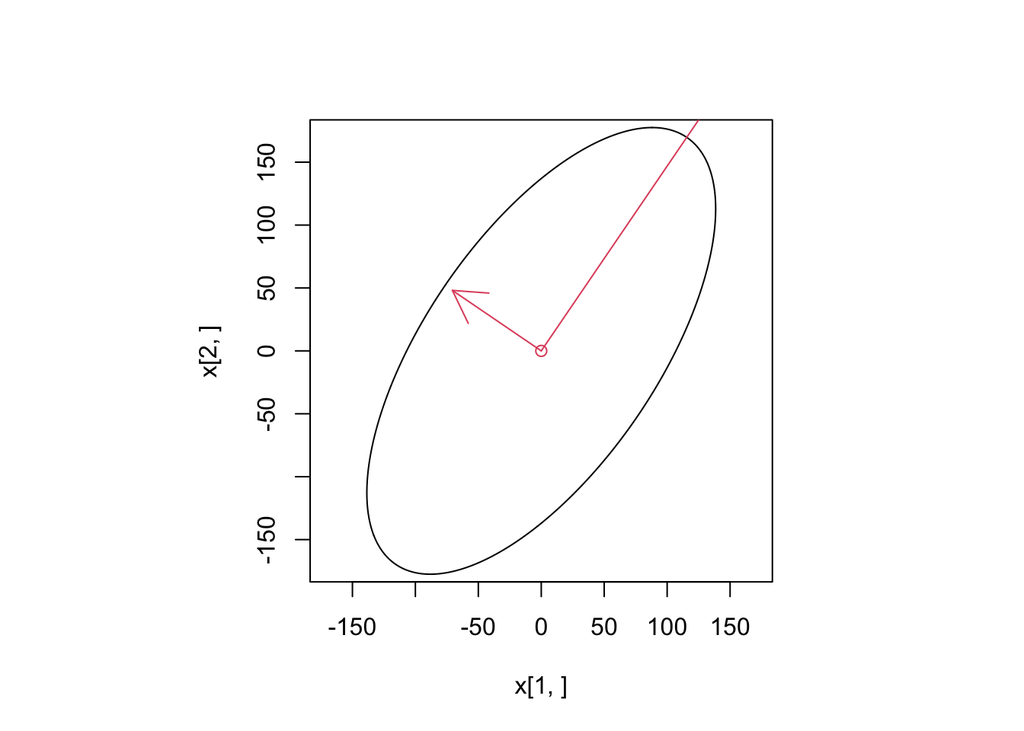

```r
par(pty="s")
plot(x[1,],x[2,],type='l', xlim=c(-170,170), ylim=c(-170,170))
points(0,0,col=2)
arrows(0,0, S.eig$values[1]*S.eig$vectors[1,1], S.eig$values[1]*S.eig$vectors[2,1], col=2)
arrows(0,0, S.eig$values[2]*S.eig$vectors[1,2], S.eig$values[2]*S.eig$vectors[2,2], col=2)
```

4. Finally, we can plot the ellipse
   $$(\mathbf x-{\boldsymbol{\mu}})^\top \mathbf S^{-1}(\mathbf x-{\boldsymbol{\mu}})=c^2$$
   by shifting the ellipse to be centered around ${\boldsymbol{\mu}}$. Thus plot the 95% confidence region for the population mean for the exam data.

**Solution**

We saw in the notes that a $100(1-\alpha)$% confidence region for ${\boldsymbol{\mu}}$ is $\{ \mathbf x: \gamma^2 \leq F_{p,n-p,\alpha} \}$, where

$$\gamma^2 = \frac{n-p}{p} (\mathbf x-\bar{\mathbf x})^\top \mathbf S^{-1} (\mathbf x-\bar{\mathbf x}).$$

So we need to draw an ellipse centred around $\bar{\mathbf x}$ with $c^2$ equal to the $F(0.95, 2,201)*2/(N-2)$.

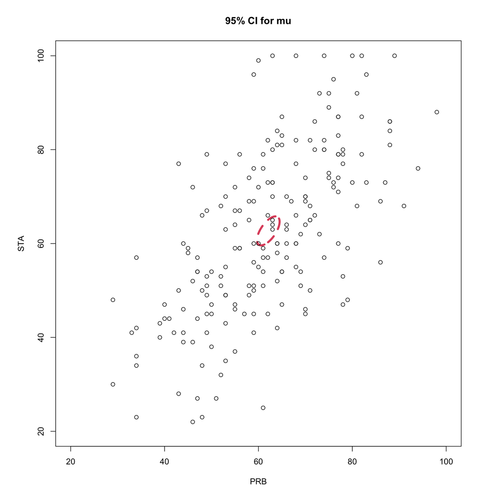

```r
const2 <-  qf(0.95, 2,201)*2/(N-2)
xbar <- colMeans(exam[,1:2])

u1<- sqrt(const2)*cos(theta)
u2 <- sqrt(const2)*sin(theta)
u <- rbind(u1,u2)

a <- Ssqrt%*% u+xbar


par(pty="s")
plot(a[1,],a[2,],type='l',xlab='PRB', ylab='STA', cex=4, xlim=c(20,100), ylim=c(20,100), col=2, lty=2, main='95% CI for mu', lwd=4)
points(exam[,1], exam[,2])
```

We can use the `confidenceEllipse` function from the `car` package to do this more easily. Unfortunately this is a little tricky as we need to estimate the means using a linear model, but it can be done as follows.

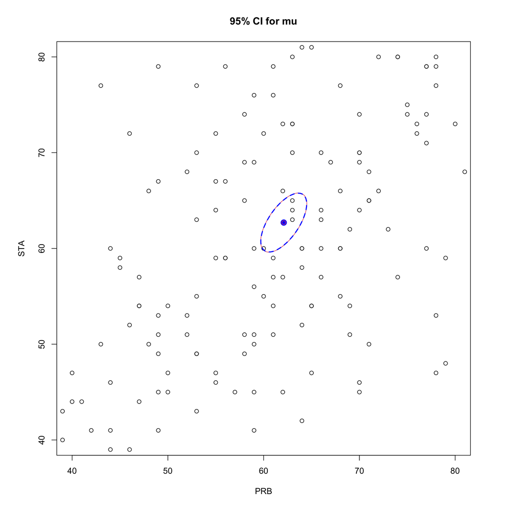

```r
library(car)
X<- as.matrix(exam[,1:2])
fit <- lm(X~1) # create a linear model object

par(pty="s")
plot(a[1,],a[2,],type='l',xlab='PRB', ylab='STA', cex=2, xlim=c(40,80), ylim=c(40,80), col=2, lty=1, main='95% CI for mu')
#dataEllipse(exam[,1], exam[,2], levels=0.05, add=TRUE)
points(exam[,1], exam[,2])
confidenceEllipse(fit, add=TRUE, lty=2)
points(xbar[1], xbar[2],col=2)
```

I’ve added this in blue on top of the region we computed ourselves so that we can confirm they are the same.